# Prise en main et premiers traitements d’une base de données sous R

Produire et analyser ses données en SHS

PUDL

Dernière modification : 2019-12-09

### 0.0.1 Données utilisées

Nous allons travailler sur des données portant sur les accidents de la route 2018 décrits par les forces de police : https://www.data.gouv.fr/fr/datasets/base-de-donnees-accidents-corporels-de-la-circulation/

**A télécharger :**

- **caractéristiques** : Circonstances générales de l’accident
- **lieux** : Caractéristiques de l’endroit où a eu lieu l’accident
- **véhicules** : Catégories de véhicules
- **usagers** : Informations sur les personnes impliquées

**Identifiants :**

- **Num_Acc** : Identifiant de l’accident
- **Num_veh** : Identifiant véhicule, un accident peut concerner plusieurs véhicules

### 0.0.2 Comment appréhender des tables de données ?

- **“Logiciels clic-boutons”** : Excel, Excel Stat… et à un autre niveau SPAD, SPSS, Sphinx, ModaLisa.

Interface avec menus et options évitant de passer par des lignes de commande. Facilité d’accès mais tâches répétitives et non enregistrées. Pas d’historique des actions effectuées. Problème de la reproductibilité et de la transférabilité des documents produits.

- **Langages de programmation** : essentiellement Python, SAS, R, SPSS…

Chaque action est produite par une ligne de commande exécutée dans un IDE (environnement de développement intégré). Historique et reproductibilité garantis, plus de possibilités.

# 1 Présentation de R et de l’environnement de travail

## 1.1 R et Rstudio

R est un dérivé gratuit (licence GNU GPL) du langage de statistique S. C’est un projet collaboratif et donc ouvert à tous. Il est entretenu par le R Development Core Team (CRAN). C’est un **langage** permettant de produire des statistiques descriptives comme des statistiques avancées. Ses fonctionnalités sont étendues ; il offre un large choix d’options graphiques. Il permet de développer ses propres fonctions et d’utiliser des fonctions développées par d’autres chercheurs, ingénieurs ou développeurs.

**En bref :**

- **Gratuit** et **opensource**
- **Multi-plateformes** (Windows, Linux, OS X)
- Produit **simplement** des statistiques avancées :
  - Statistiques descriptives, inférentielles
  - Représentations graphiques
  - Analyses factorielles
  - Modélisations
  - Analyses de réseaux
  - Cartographies, etc.
- Grâce aux **“packages”** (extensions, bibliothèques de fonctions), les fonctionnalités sont très étendues et en font un langage complet
- Importante **communauté** :
  - Tutoriels et aides sur le web
  - Développement constant de nouvelles fonctionnalités, interfaces et mises à jour régulières
- **Reproductibilité** et **historique** :
  - **Partager** simplement des **rapports commentés** (pdf, word, htlm, présentations) et **applications en ligne** ;
  - **Reproduire** et adapter des procédures et méthodes réalisées pour d’autres projets (ex : Rapports annuels);
- Permet de ne pas subir des options par défaut sans les comprendre
- **Compatible** avec d’autres langages, **exportations graphiques** avancées

*… Quelques inconvénients :*

- Les fonctionnalités (et bibliothèques) sont très souvent mises à jour et nécessitent d’être maintenues.
- Les fonctionnalités sont créées par les contributeurs et les syntaxes peuvent être variées

**Téléchargements et environnement :**

La console diponible avec R (RGui) est rudimentaire. Il est conseillé d’utiliser un logiciel offrant un espace de travail plus agréable. **RStudio** est un environnement de développement pour l’écriture et la visualisation de scripts R. Il est également libre et gratuit. Il offre un éditeur de texte (coloration, auto complétion, indentation) et un affichage simultané des scripts, sorties, fichiers, graphiques, aides.

**- (1) Télécharger le langage R :**

https://cran.r-project.org/

Puis “download R for…” suivant votre système d’exploitation (base pour Windows, R-3.6.1.pkg pour mac et sudo apt-get install r-base r-base-dev dans le terminal pour linux)

**- (2) Télécharger et installer l’IDE RStudio :**

La console diponible avec R (RGui) est rudimentaire. On utilisera l’IDE **RStudio** (auto-complétion, coloration, indentation, erreurs de syntaxe mises en évidence, gestion des scripts, visualisations, projets, affichage simultané des scripts, sorties, fichiers, graphiques, aides).

- **RStudio** : https://www.rstudio.com/products/rstudio/download/#download

### 1.1.1 Environnement de RStudio

[figure not shown]

- **Console** : Retour direct des instructions (**sans sauvegarde**). La console permet de vérifier que les lignes de commande ont bien été exécutées et de comprendre les erreurs éventuelles afin de les corriger. **“>” = prêt à recevoir des instructions.**

Instruction simple :

```r
1+1
```

Et touche Entrée

- **Script** : Zone d’écriture des instructions qui constitue le programme ou script qui sera **gardé en mémoire** (après sauvegarde) Pour ouvrir un script : ctrl+shift+N / Fichier > new file > R script

```r
1+1
```

Sélectionner la ligne puis Ctrl + entrée ou bouton “Run”. Ou “Source” pour tout exécuter

### 1.1.2 Créer un objet dans R

Dans R, on manipule des **objets** qu’on crée directement dans l’interface. En fait, ce sont des objets virtuels qui n’existent que dans la session de travail. Pour créer un objet, on lui donne un nom, puis on écrit **<-** afin de signaler qu’on va définir un contenu à cet objet, enfin on définit son contenu :

```r
# Création d'une valeur
Objet <- 5
Objet + Objet
Objet <- Objet + 2
Objet + Objet
class(Objet)
# Création d'une chaîne de caractères
Texte <- "Mon texte"
Texte
# texte
class(Texte)

# Supprimer des objets :
rm(Texte)
rm(Objet)
# ou rm(Texte, Objet)
```

**Attention :**

- Respect de la casse
- Ni accent, ni espace, ni caractère spécial en-dehors de “_"

Les objets peuvent être de différentes natures : chaîne de caractère, chiffre, suite d’éléments (vecteur), tableau, matrice, image, graphique, etc. Ils sont toujours accessible par déclaration et créés/édités avec “<-”

### 1.1.3 Utiliser des fonctions dans R

R est un langage orienté vers les objets qui sont au centre des manipulations produites. Les actions sont réalisées à l’aide de **fonctions** qui agissent sur des **objets**. Les fonctions sont déclarées par leurs noms et suivies de parenthèses : **fonction()**. A l’intérieur des fonctions, on déclare un ou plusieurs **arguments** : les **objets** et des **options**.

```r
A <- 14.5646
print(A, digits = 4)
```

```
## [1] 14.56
```

```r
round(A)
```

```
## [1] 15
```

```r
round(A, digits = 2)
```

```
## [1] 14.56
```

```r
trunc(A)
```

```
## [1] 14
```

où **print** est la fonction “imprime”, **A** l’objet à imprimer, **digits = 4** l’option “quatre chiffres”.

Par défaut, notations anglosaxonnes (. ou décimales)

```r
?print
```

- **Menus** :
  - **Fichiers** : Nouveau fichier (script, présentation), ouvrir fichier, enregistrer, fichiers récents
  - **Outils** : Installer package (gmodels), options
  - **Session** : Actions sur la session de travail

### 1.1.4 Les packages

- **Packages** : Extensions ajoutées à votre session de travail, une fois installées et chargées. Les packages sont des **bibliothèques de fonctions** supplémentaires développées par d’autres personnes.
- Les packages “officiels” sont validés par la communauté de R (CRAN). Ils sont tous **accompagnés d’une documentation** (document pdf issu du site cran.r-project.org).

Pour utiliser un package validé par le CRAN :

- *1. L’installer* **(une seule fois)**

```r
install.packages("tidyverse", dep=T)
```

*Cette étape d’installation des packages est délicate : R évoluant rapidement, la compatibilité entre les packages et entre les packages et la version utilisée de R n’est toujours maintenue.*

Installer également `questionr`

- **2. Le charger** **(à refaire pour chaque session)**.
  - En ligne de commande :

```r
library(tidyverse)
library(questionr)
```

**/!\ Il est préférable d’écrire ces lignes afin que les packages soient automatiquement définis et que les fonctions associées fonctionnent.**

**On recommande aussi de mettre ces lignes en début de script.**

*library() est équivalent à require()*

**Enregistrer votre script : File > Save as…**

### 1.1.5 Organiser son travail

Quand on entame un projet, les lignes de commande, scripts, tableaux créés et dossiers peuvent s’accumuler. Il est important d’organiser son travail dès le début.

**Gérer ses projets** :

Vous créez un dossier par projet. Ce dossier est directement relié à votre projet et comporte des sous-dossiers “données”, “scripts”, “sorties” par exemple.

Dès maintenant, créez un dossier pour le TD, comprenant des sous-dossiers : - data : données importées - sorties : tableaux et graphiques créés

Et enregistrez le script en cours dans ce dossier : “dataSHS_19.R”

En haut à droite, un icône permet de créer un **“nouveau projet”**. C’est un assistant de création d’un **dossier** dédié à un projet spécifique dans votre explorateur (windows, mac ou linux). Il sera associé à une **session de Rstudio**, qui sera indépendante des documents et objets utilisés pour un autre projet.

ou bien File > New Project > Existing directory –> Browse > Sélectionner votre dossier créé pour le TD > Create project

Un fichier **Nom_du_dossier.Rproj** apparaît dans le dossier, c’est le raccourci qui mènera à la session R. Un fichier **.RData** sera également créé et contiendra les tableaux présents dans l’environnement.

**Commentaires :**

Lire ou relire un programme, ce n’est pas lire un roman. Ca peut être fastidieux, surtout lorsque le programme n’est pas commenté.

Les commentaires permettent de comprendre la logique engagée sur une partie de programme, de préciser l’utilisation d’une fonction et d’organiser un script. Les commentaires sont précédés de **#** et ne sont pas exécutés.

Pour passer un ensemble sélectionné en commentaire (et inversement) : **ctrl+shift+c**.

Aérer le texte et mettre des titres facilitent aussi grandement la lecture de scripts : sur une ligne, **# Titre ----**

**Enfin, il y a plusieurs façons d’arriver à un résultat recherché ; Il s’agit déjà de comprendre ce qu’on fait. On préferera l’écriture la plus concise et compréhensible**

# 2 Importer des données

## 2.1 Création directe de tableaux

Méthode peu utilisée mais à connaître pour comprendre la logique de création des objets.

Un tableau peut être considéré comme une juxtaposition de colonnes (vecteurs) + **1. Soit on crée les colonnes (vecteurs) qu’on agrège ensuite :**

```r
vectA <- c(1,2,3,4,5) # Le vecteur vectA est constitué des observations 1, 2, 3, 4 et 5 ;
# La fonction c() permet de décrire une suite d'éléments séparés par des virgules,
# ces éléments sont des 'arguments' de la 'fonction' c().

vectB <- c("A","B","C","D","E")
# Le vecteur vectB est constitué d'éléments entre guillemets, ce sont des "chaînes de caractère".
# Sans guillemets, R cherchera les objets nommés A, B, C, D et E qui n'existent pas.
# vectB <- c(A,B,C,D,E) # ne fonctionne pas

table <- data.frame(vectA,vectB)
# Constitution du tableau ; /!\ les vecteurs doivent être de même taille
# (avec un nombre identique d'éléments) pour être agrégés en tableau
vectC <- c(4,3)
# table <- data.frame (vectA, vectC) # ne fonctionne pas
head(table) # Visualise ls premières lignes de la table dans la console
```

- **2. Soit on crée un tableau directement :**

En condensant les étapes ci-dessus :

```r
DepRegHDF <- data.frame(Departement=c("59","62","02","60","80"),
                      LibDep=c("Nord", "Pas-de-Calais", "Aisne", "Oise", "Somme"),
                      LibExReg=c("Nord Pas-de-Calais","Nord Pas-de-Calais","Picardie","Picardie","Picardie"))
DepRegHDF
```

| Departement | LibDep | LibExReg |
| --- | --- | --- |
| 59 | Nord | Nord Pas-de-Calais |
| 62 | Pas-de-Calais | Nord Pas-de-Calais |
| 02 | Aisne | Picardie |
| 60 | Oise | Picardie |
| 80 | Somme | Picardie |

## 2.2 Importations

En général, on ne saisit pas directement les données dans R, elles sont recueillies dans un autre fichier qu’on importe dans R en créant un nouvel objet.

Le fichier source peut être en format :

- Texte (.txt, .csv),
- Tableur : Excel (xls, xlsx), Calc (.ods),
- Tables issues de logiciels statistiques : SAS (.sas7bdat), SPSS (sav),
- Format R : (.RData)
- html, xml, json, etc.

Plusieurs packages facilitent l’importation directe de tableaux de données enregistrés dans divers formats (ex : package xlsx).

Quelques exemples :

### 2.2.1 Fichiers textes (cvs, txt)

Les fichiers sont enregistrés en CSV dans le sous-dossier “data/BAAC2018” :

```r
caract <-read.csv("data/BAAC2018/caracteristiques-2018.csv",
                  fileEncoding = "ISO-8859-1",
                  stringsAsFactors = F)
# argument nécessaire : "SousDossiers/NomFichier.csv"
# arguments utiles dans ce cas :
# - fileEncoding = format d'encodage des caractères
# - stringsAsFactors = F ; ne pas transformer les chaînes de caractères en facteurs (modalités enregistrées en codes)
# arguments par défaut :
# header = TRUE/FALSE : La première ligne correspond-elle aux titres des variables ?
# sep = "," : Choix du caractère séparant les cellules du tableau
# dec ="," : Choix du caractère des décimales
```

`read.csv2` quand le séparateur est le “;”

`read.table` pour les fichiers .txt et séparateur = “”

```r
lieux <-read.csv("data/BAAC2018/lieux-2018.csv",
                  fileEncoding = "ISO-8859-1",
                  stringsAsFactors = F)
vehicules <-read.csv("data/BAAC2018/vehicules-2018.csv",
                  fileEncoding = "ISO-8859-1",
                  stringsAsFactors = F)
usagers <-read.csv("data/BAAC2018/usagers-2018.csv",
                  fileEncoding = "ISO-8859-1",
                  stringsAsFactors = F)
```

### 2.2.2 Fichiers tableurs (xls, xlsx)

Pour les fichiers excel : **Package readxl** :

```r
library(readxl)
table <-read_excel("fichier.xlsx", sheet = 3) # ou read_xlsx
```

Fichiers dbf :

```r
library(foreign)
table <- read.dbf("mtcars.dbf", as.is = TRUE ) # as.is = TRUE pour modifier les variables qualitatives en factor
```

### 2.2.3 Tableaux d’autres logiciels statistiques (sas, spss)

Pour les bases de logiciels de statistiques (sas, spss, stata) : **Package haven** :

```r
install.packages("haven", dep=T)
library(haven)

# SAS
table <- read_sas("mtcars.sas7bdat")
write_sas(table, "mtcars.sas7bdat")

# Stata
table <- read_dta("mtcars.dta")
write_dta(table, "mtcars.dta")

# SPSS
table <- read_sav("mtcars.sav")
write_sav(table, "mtcars.sav")
```

Cf : https://github.com/tidyverse/haven

### 2.2.4 Objet(s) R

#### 2.2.4.1 Un objet R

Fichier .rds :

```r
readRDS("my_data.rds")
ChangementDeNom <- readRDS("my_data.rds")
```

#### 2.2.4.2 Plusieurs objets R

… Contenus dans un fichier .RData (ou .rda) :

```r
load("data.RData") # Restaure un environnement (ensemble des objets) enregistré au préalable
```

### 2.2.5 Table contenue dans un package R

```r
library(questionr)
data(package="questionr") # Connaître les données disponibles avec le package
```

```r
data(hdv2003)
```

## 2.3 Exporter des données

Format R (un objet) :

```r
saveRDS(Table, "Table.rds")
Table <- readRDS("Table.rds")
```

Ensemble de l’environnement :

```r
save(table1, table2, matrice, file = "mydata.RData")
# ou
save.image("mydata.RData") # note : .rda équivalent à .RData
load("mydata.RData")
# /!\ importe l'ensemble, même si les objets existent déjà
```

Fichier texte :

```r
write.csv2(Table, "Table.csv", fileEncoding = "UTF-8", na="", row.names = F)
write.table(Table, "Table.txt", sep="\t", fileEncoding = "UTF-8")
```

# 3 Mise en forme des données

## 3.1 Premier aperçu d’une table

```r
head(lieux) # Aperçu des 1ères lignes
```

|  | Num_Acc | catr | voie | v1 | v2 | circ | nbv | pr | pr1 | vosp | prof | plan | lartpc | larrout | surf | infra | situ | env1 |
| --- | --- | --- | --- | --- | --- | --- | --- | --- | --- | --- | --- | --- | --- | --- | --- | --- | --- | --- |
| 1 | 2.018e+11 | 3 | 41 | NA | C | 2 | 2 | NA | NA | 0 | 1 | 3 | NA | NA | 1 | 0 | 1 | 0 |
| 2 | 2.018e+11 | 4 | 41 | NA | D | 2 | 2 | NA | NA | 0 | 1 | 2 | NA | NA | 1 | 0 | 1 | 0 |
| 3 | 2.018e+11 | 3 | 39 | NA | D | 2 | 2 | NA | NA | 0 | 1 | 1 | NA | NA | 1 | 0 | 1 | 0 |
| 4 | 2.018e+11 | 3 | 39 | NA |  | 2 | 2 | NA | NA | 0 | 1 | 1 | NA | NA | 1 | 0 | 1 | 0 |
| 5 | 2.018e+11 | 4 |  | NA |  | 1 | 1 | NA | NA | 0 | 1 | 1 | NA | NA | 1 | 0 | 1 | 0 |
| 6 | 2.018e+11 | 3 | 39 | NA | D | 0 | 2 | NA | NA | 0 | 2 | 2 | NA | NA | 2 | 0 | 3 | 0 |

```r
dim(lieux) # dimension du tableau
```

```
## [1] 57783    18
```

```r
names(lieux) # Nom des variables
```

```
##  [1] "Num_Acc" "catr"    "voie"    "v1"      "v2"      "circ"    "nbv"
##  [8] "pr"      "pr1"     "vosp"    "prof"    "plan"    "lartpc"  "larrout"
## [15] "surf"    "infra"   "situ"    "env1"
```

```r
str(caract) # Nom, type des variables et premières observations
```

```
## 'data.frame':    57783 obs. of  16 variables:
##  $ Num_Acc: num  2.02e+11 2.02e+11 2.02e+11 2.02e+11 2.02e+11 ...
##  $ an     : int  18 18 18 18 18 18 18 18 18 18 ...
##  $ mois   : int  1 2 3 5 6 9 9 11 2 3 ...
##  $ jour   : int  24 12 4 5 26 23 26 30 18 19 ...
##  $ hrmn   : int  1505 1015 1135 1735 1605 630 40 1715 1557 1530 ...
##  $ lum    : int  1 1 1 1 1 2 5 5 1 1 ...
##  $ agg    : int  1 2 2 2 2 2 2 2 1 2 ...
##  $ int    : int  4 7 3 1 1 1 1 1 1 2 ...
##  $ atm    : int  1 7 1 7 1 2 1 1 1 1 ...
##  $ col    : int  1 7 7 3 3 6 6 6 6 1 ...
##  $ com    : int  5 11 477 52 477 52 133 11 550 51 ...
##  $ adr    : chr  "route des Ansereuilles" "Place du général de Gaul" "Rue  nationale" "30 rue Jules Guesde" ...
##  $ gps    : chr  "M" "M" "M" "M" ...
##  $ lat    : int  5055737 5052936 5051243 5051974 5051607 5052132 5052211 5053146 5053707 5053639 ...
##  $ long   : int  294992 293151 291714 289123 290605 288837 296652 293875 284896 281517 ...
##  $ dep    : int  590 590 590 590 590 590 590 590 590 590 ...
```

## 3.2 Recodages de modalités

En général, comme pour ces tables, un tableau de données doit être retravaillé et mis en forme avant d’être utilisé pour produire des statistiques et graphiques pertinents. Une des limites du langage R est aussi une de ses qualités : la possibilité de créer et de diffuser des fonctions et des packages facilement implique que, selon les packages utilisés, la syntaxe peut varier.

Le package `tidyverse` regroupe d’autres packages complémentaires qui ont été pensés selon une syntaxe commune et dont les principaux sont :

- `readr` : importation
- `tibble` : format des tableaux de données
- `forcats` : mise en forme des facteurs
- `stringr` : modification de chaînes de caractères
- `tidyr` et `dplyr` : mise en forme de tableaux
- `ggplot2` : graphiques

On verra des fonctions de la syntaxe de base de R et de la syntaxe `tidyverse`.

L’opération de base de remise en forme de base consiste à recoder les modalités.

**Les opérateurs utiles :**

- == : Egalité (A == B signifie “A est égal à B”)
- != : Exclusion ( A != B signifie “A est différent de B”)
- < , > , <= , >= : inférieur, supérieur, inférieur ou égal, supérieur à égal
- %in% : appartient à

**Enchaînement de plusieurs conditions :**

- | : Ou bien
- & : Et

### 3.2.1 Recodage par assignation d’une variable qualitative

```r
names(usagers)
```

```
##  [1] "Num_Acc" "place"   "catu"    "grav"    "sexe"    "trajet"  "secu"
##  [8] "locp"    "actp"    "etatp"   "an_nais" "num_veh"
```

```r
head(usagers$sexe)
```

```
## [1] 1 1 1 1 1 1
```

```r
class(usagers$sexe)
```

```
## [1] "integer"
```

```r
usagers$sexe <- as.character(usagers$sexe)
class(usagers$sexe)
```

```
## [1] "character"
```

```r
usagers$sexe [ usagers$sexe == "1"] <- "Homme"
usagers$sexe [ usagers$sexe == "2"] <- "Femme"
head(usagers$sexe)
```

```
## [1] "Homme" "Homme" "Homme" "Homme" "Homme" "Homme"
```

- Modifier en réel entier (integer) : as.integer()
- Modifier en réel à décimales (numeric) : as.numeric()
- Modifier en variable binaire (logical) : as.logical()
- Modifier en date : as.Date() :

Avec la syntaxe `tidyverse`, le recodage peut se faire terme à terme avec `fct_recode` our en regroupant plusieurs modalités avec `fct_collapse`. Attention, elles portent sur des variables de type `facteur` :

```r
# grav
usagers$grav <- factor(usagers$grav)
usagers$grav <- fct_recode(usagers$grav,
                                 "Indemne"="1",
                                 "Tué" ="2",
                                 "Blessé hospitalité"="3",
                                 "Blessé léger"="4")
levels(usagers$grav)
```

```
## [1] "Indemne"            "Tué"                "Blessé hospitalité"
## [4] "Blessé léger"
```

```r
# traj
usagers$trajet <- factor(usagers$trajet)
usagers$trajet <- fct_recode(usagers$trajet,
                                 "Domicile/travail"="1",
                                 "Domicile/école" ="2",
                                 "Courses/achats"="3",
                                 "Trajet professionnel"="4",
                                 "Promenade/loisirs"="5",
                                 "Autre"="9")
levels(usagers$trajet)
```

```
## [1] "0"                    "Domicile/travail"     "Domicile/école"
## [4] "Courses/achats"       "Trajet professionnel" "Promenade/loisirs"
## [7] "Autre"
```

```r
# catu
usagers$catu <- factor(usagers$catu)
usagers$catu  <- fct_collapse(usagers$catu ,
"Piéton" = c("3","4"),
"Conducteur"="1",
"Passager"="2")
```

### 3.2.2 Calculs sur les variables

```r
usagers$age <- 2018 - usagers$an_nais
```

### 3.2.3 Création de catégories

```r
# En 5 classes d'amplitude égale
usagers$age.classe <- cut(usagers$age, 5)
# Selon les bornes définies
usagers$age.classe.majorite <- cut(usagers$age, c(0,18,110), right=F)
# Selone une séquence définie
usagers$age.classe.decennies <- cut(usagers$age, seq(0,110,10), right=F)
# Selon des quantiles
usagers$age.classe.quartiles <- cut(usagers$age, quantile(usagers$age, seq(0,1,.25), na.rm=T), right=F)
```

### 3.2.4 Créer une variable à partir d’autres variables

Fonction **ifelse(condition, si condition remplie, si condition non remplie)** :

```r
usagers$Majorite <- ifelse (usagers$age < 18, "mineur","majeur")
```

```r
# unique(caract$dep)
caract$dep <- ifelse(nchar(caract$dep)==2,
                               paste0("0", caract$dep),
                               caract$dep)
# nchar() : nombre de caractères
# paste0() : concaténation sans séparateur
caract$HdF <- ifelse (caract$dep %in% c("590","620","800","600","020"), "Hauts de France", "Hors Hauts de France")
```

### 3.2.5 Recodages de la table Caractéristiques

```r
# Luminosité
caract$lum <- fct_collapse(factor(caract$lum),
                           "Jour"="1",
                           "Aube/crépuscule"="2",
                           "Nuit (sans écl.)"=c("3","4"),
                           "Nuit (avec écl.)"="5")
# Agglomération
caract$agg <- fct_recode(factor(caract$agg),
                           "Hors agglo."="1",
                           "En agglo."="2")


# Conditions atmosphériques
caract$atm <- fct_recode(factor(caract$atm),
                         "Normales"="1",
                         "Pluie légère"="2",
                         "Pluie forte" ="3",
                         "Neige, grêle"="4",
                         "Brouillard"="5",
                         "Vent fort, tempête"="6",
                         "Temps éblouissant"="7",
                         "Temps couvert"="8",
                         "Autre" = "9")
```

### 3.2.6 Recodages de la table lieux

```r
lieux$catr[lieux$catr=="1"]<-"Autoroute"
lieux$catr[lieux$catr=="2"]<-"Nationale"
lieux$catr[lieux$catr=="3"]<-"Départementale"
lieux$catr[lieux$catr=="4"]<-"Communale"
lieux$catr[lieux$catr=="5"]<-"Hors réseau public"
lieux$catr[lieux$catr=="6"]<-"Parking"
lieux$catr[lieux$catr=="9"]<-"Autre"


lieux$surf[lieux$surf=="1"]<-"Normale"
lieux$surf[lieux$surf=="2"]<-"Mouillée"
lieux$surf[lieux$surf=="3"]<-"Flaques"
lieux$surf[lieux$surf=="4"]<-"Innondée"
lieux$surf[lieux$surf=="5"]<-"Enneigée"
lieux$surf[lieux$surf=="6"]<-"Boue"
lieux$surf[lieux$surf=="7"]<-"Verglas"
lieux$surf[lieux$surf=="8"]<-"Gras, huile"
lieux$surf[lieux$surf=="9"]<-"Autre"
lieux$surf[lieux$surf=="0"]<-"NR"
lieux$surf[is.na(lieux$surf)]<-"NR"


lieux$situ [ lieux$situ == '1'] <- "Chaussée"
lieux$situ [ lieux$situ == '2'] <- "Bande d'arrête d'urgence"
lieux$situ [ lieux$situ == '3'] <- "Accotement"
lieux$situ [ lieux$situ == '4'] <- "Trottoir"
lieux$situ [ lieux$situ == '5'] <- "Piste cyclable"


lieux$circ <- fct_recode(factor(lieux$circ),
                              "Sens unique" = "1",
                              "Bidirectionnel" = "2",
                              "Chaussées séparées" = "3",
                              "Vois d'affectation variable" = "4")

lieux$vosp <- fct_recode(factor(lieux$vosp),
                            "Piste cyclable"="1",
                            "Bande cyclable" = "2",
                            "Voie réservée" = "3",
                            "Pas d'amménagement" = "0")
```

### 3.2.7 Recodages de la table Véhicules

```r
vehicules$catv <- as.integer(vehicules$catv)


vehicules$Vehicule <- case_when(vehicules$catv==1 ~ "2 roues non motorisé",
                                (vehicules$catv>1 & vehicules$catv<7) ~ "2 roues motorisé",
                                 (vehicules$catv>=7 &
                                vehicules$catv<=9)~ "Voiture",
                                (vehicules$catv>=10 &
                                vehicules$catv<=12)~ "Utilitaire",
                                (vehicules$catv>=13 &
                                vehicules$catv<=15)~ "Poids lourd",
                                (vehicules$catv>=16 &
                                vehicules$catv<=17)~ "Tracteur",
                                (vehicules$catv==19 |
                                vehicules$catv==40)~ "Tramway",
                                (vehicules$catv==21)~ "Tracteur",
                                (vehicules$catv>=30 &
                                vehicules$catv<=34)~ "2 roues motorisé",
                                (vehicules$catv>=35 &
                                vehicules$catv<=36)~ "Quad",
                                (vehicules$catv>=37 &
                                vehicules$catv<=38) ~ "Bus",
                                vehicules$catv==39 ~ "Train",
                                (vehicules$catv==20 |
                                vehicules$catv==99)~ "Autre",
                                T ~ "")


vehicules$Vehicule <- fct_collapse(vehicules$Vehicule,
                                  "Voitures, utilitaires" = c("Voiture","Utilitaire"),
                                  "Poids lourds / tram / train" = c("Bus","Poids lourd","Tracteur","Bus", "Tramway","Train"),
                                  "2 roues motorisés / quad" = c("2 roues motorisé", "Quad") )
```

### 3.2.8 Recodage de l’heure de l’accident

```r
## Heure de l'accident :
## Etape 1 : Ajouter les zéros manquants en début d'observation
caract$hrmn <- as.character(caract$hrmn)
caract$hrmn<- case_when (nchar(caract$hrmn)==3 ~
                        paste0("0",caract$hrmn),
                        nchar(caract$hrmn)==2 ~
                        paste0("00",caract$hrmn),
                        nchar(caract$hrmn)==1 ~
                        paste0("000",caract$hrmn),
                       nchar(caract$hrmn)==4 ~ caract$hrmn,
                               T ~ "")

# Etape 2 : conserver les heures uniquement (2 premiers caractères) :
# fonction substr(variable, 1er caract, dernier caract)
substr("abcd",1,2)
```

```
## [1] "ab"
```

```r
caract$hrmn <- substr(caract$hrmn,
                        1,2)
freq(caract$hrmn )
```

|  | n | % | val% |
| --- | --- | --- | --- |
| 00 | 1021 | 1.8 | 1.8 |
| 01 | 882 | 1.5 | 1.5 |
| 02 | 640 | 1.1 | 1.1 |
| 03 | 637 | 1.1 | 1.1 |
| 04 | 571 | 1.0 | 1.0 |
| 05 | 881 | 1.5 | 1.5 |
| 06 | 1224 | 2.1 | 2.1 |
| 07 | 2499 | 4.3 | 4.3 |
| 08 | 3438 | 5.9 | 5.9 |
| 09 | 2963 | 5.1 | 5.1 |

[output cut: 14 more lines]

```r
caract$hrmn <- factor(caract$hrmn)
caract$hrmnCl <- fct_collapse(caract$hrmn,
                                 "00h-06h" = c("00","01","02","03","04","05"),
                                 "06h-10h" = c("06","07","08","09"),
                                 "10h-14h" = c("10","11","12","13"),
                                 "14h-17h" = c("14","15","16"),
                                 "17h-20h" = c("17","18","19"),
                                 "20h-00h" = c("20","21","22","23"))

cprop(table(caract$lum,
      caract$hrmnCl))
```

```
##
##                    00h-06h 06h-10h 10h-14h 14h-17h 17h-20h 20h-00h Ensemble
##   Jour               0.5    72.6    99.9    98.1    61.4    12.9    67.0
##   Aube/crépuscule    4.1    14.9     0.1     1.8     9.6     9.0     6.6
##   Nuit (sans écl.)  44.5     5.8     0.0     0.0    10.7    28.5    10.6
##   Nuit (avec écl.)  50.9     6.7     0.0     0.1    18.3    49.6    15.7
##   Total            100.0   100.0   100.0   100.0   100.0   100.0   100.0
```

## 3.3 Sélections, filtres et tris

En **R-base**, les tableaux de données sont des dataframes dont la structure est :

**Tableau [ lignes , colonnes ]**.

Concrètement :

Sélectionner et filtrer **des lignes** :

```r
usagers[1:3 , ] # 3 premières lignes
usagers[usagers$age<18 , ] # usagers de moins de 18 ans
usagersF <- usagers[usagers$sexe=="Femme" , ]
```

Sélectionner **des colonnes** :

```r
Moment <- caract [ , c("Num_Acc", "mois", "jour", "hrmn")]
```

En revanche, en **Tidyverse**, les données sont représentées dans des **tibbles**. En réalité, toutes les fonctions de Tidyverse agissant sur des data.frames rendront des tibbles. Ils ne sont pas très différents des data.frames :

- Pas de rownames
- Espaces, caractères spéciaux et nombres en noms de colonne possibles
- Affichage : premières lignes, dimensions, types de colonnes

Actions sur leur structure : **fonction ( table, condition)**

### 3.3.1 Sélection de lignes : `slice`…

```r
# 4 premières lignes :
slice(usagers,1:4)
```

| Num_Acc | place | catu | grav | sexe | trajet | secu | locp | actp | etatp | an_nais | num_veh | age | age.classe | age.classe.majorite | age.classe.decennies | age.classe.quartiles | Majorite |
| --- | --- | --- | --- | --- | --- | --- | --- | --- | --- | --- | --- | --- | --- | --- | --- | --- | --- |
| 2.018e+11 | 1 | Conducteur | Blessé hospitalité | Homme | 0 | 11 | 0 | 0 | 0 | 1928 | B01 | 90 | (85.6,107] | [18,110) | [90,100) | [52,107) | majeur |
| 2.018e+11 | 1 | Conducteur | Indemne | Homme | Promenade/loisirs | 11 | 0 | 0 | 0 | 1960 | A01 | 58 | (42.8,64.2] | [18,110) | [50,60) | [52,107) | majeur |
| 2.018e+11 | 1 | Conducteur | Indemne | Homme | 0 | 11 | 0 | 0 | 0 | 1947 | A01 | 71 | (64.2,85.6] | [18,110) | [70,80) | [52,107) | majeur |
| 2.018e+11 | NA | Piéton | Blessé léger | Homme | 0 | 2 | 2 | 3 | 1 | 1959 | A01 | 59 | (42.8,64.2] | [18,110) | [50,60) | [52,107) | majeur |

### 3.3.2 et de colonnes `select` :

```r
 # sélection de "id" et des colonnes contenant "groupe" :
Date <- caract %>%
  select(Num_Acc, mois, jour, hrmn)
```

### 3.3.3 Filtres : `fliter` :

```r
usagersPietons <- filter(usagers, catu=="Piétons")
```

### 3.3.4 Trier des données

`arrange` :

```r
usagers <- arrange(usagers, desc(age))
slice(usagers,1:5)
```

| Num_Acc | place | catu | grav | sexe | trajet | secu | locp | actp | etatp | an_nais | num_veh | age | age.classe | age.classe.majorite | age.classe.decennies | age.classe.quartiles | Majorite |
| --- | --- | --- | --- | --- | --- | --- | --- | --- | --- | --- | --- | --- | --- | --- | --- | --- | --- |
| 201800055647 | 2 | Passager | Indemne | Homme | Promenade/loisirs | 11 | NA | NA | NA | 1911 | A01 | 107 | (85.6,107] | [18,110) | [100,110) | NA | majeur |
| 201800007179 | 2 | Passager | Blessé léger | Femme | Promenade/loisirs | 11 | 0 | 0 | 0 | 1916 | A01 | 102 | (85.6,107] | [18,110) | [100,110) | [52,107) | majeur |
| 201800023257 | NA | Piéton | Blessé léger | Femme | Promenade/loisirs | 3 | 8 | 9 | 2 | 1916 | A01 | 102 | (85.6,107] | [18,110) | [100,110) | [52,107) | majeur |
| 201800046023 | 1 | Conducteur | Blessé léger | Homme | 0 | 11 | NA | NA | NA | 1917 | A01 | 101 | (85.6,107] | [18,110) | [100,110) | [52,107) | majeur |
| 201800000977 | NA | Piéton | Tué | Homme | Courses/achats | 3 | 4 | 3 | 1 | 1918 | A01 | 100 | (85.6,107] | [18,110) | [100,110) | [52,107) | majeur |

## 3.4 L’opérateur `%>%` (pipe)

L’opérateur `%>%` (*pipe*, ctrl+shift+m) permet d’enchaîner des fonctions :

Sans le pipe, on peut encaster les fonctions ou les écrire à la suite.

```r
slice(
  select(
    arrange(
      filter(
        usagers, sexe=="Homme"),
      desc(age)),
    age, grav, catu),
  1:2)
```

| age | grav | catu |
| --- | --- | --- |
| 107 | Indemne | Passager |
| 101 | Blessé léger | Conducteur |

… pas très lisible (il faut lire de l’intérieur vers l’extérieur), difficile de voir les arguments associés à chaque fonction.

Le pipe permet d’enchainer les fonctions en prenant comme argument principal le résultat de la fonction précédente : `f(a)` s’écrit `a %>% f()`.

table %>% fonction1() %>% fonction2()

au lieu de fonction2(fonction1(table))

Ce qui, pour l’exemple, donne :

```r
usagers %>%
  filter(sexe=="Homme") %>%
  arrange(desc(age)) %>%
  select(age, grav, catu) %>%
  slice(1:2)
```

| age | grav | catu |
| --- | --- | --- |
| 107 | Indemne | Passager |
| 101 | Blessé léger | Conducteur |

# 4 Jointures de tables

Les données sur les accidents sont organisées en plusieurs tables relatives à plusieurs unités statistiques (l’événement “accident”, les véhicules impliqués et les usagers impliqués). Il est toutefois possible de les regrouper si on dispose d’une clé d’appariemment (une variable commune à deux tables permettant d’associer les accidents avec les personnes et les véhicules concernés).

Exemple 1 : Jointure des tables “Caractéristiques” et “lieux” :

```r
Accident <- merge (x = caract, y = lieux, by = "Num_Acc")
```

Exemple 2 : Ajout des caractéristiques de l’accident dans la table usagers :

```r
usagers <- merge (x = usagers, y = Accident, by = "Num_Acc", all.x = T)
```

Exemple 3 : Ajout des données sur les véhicules dans la table usagers :

```r
usagers <- merge (usagers, vehicules, by = c("Num_Acc","num_veh"), all.x = T)
```

# 5 Traitements et graphiques avec `ggplot2`

## 5.1 Représenter une variable

### 5.1.1 Variable qualitative

#### 5.1.1.1 Effectifs

```r
table(usagers$sexe) # Nombre d'observations pour chaque modalité
```

```
##
## Femme Homme
## 41951 88218
```

```r
table(usagers$sexe, useNA="ifany") # Ajout des NA : Non-attribués
```

```
##
## Femme Homme
## 41951 88218
```

```r
addmargins(table(usagers$sexe, useNA="ifany")) # Ajout de l'ensemble
```

```
##
##  Femme  Homme    Sum
##  41951  88218 130169
```

#### 5.1.1.2 Pourcentages

```r
prop.table(table(usagers$sexe))*100 # En pourcentages
```

```
##
##   Femme   Homme
## 32.2281 67.7719
```

```r
round(prop.table(table(usagers$sexe))*100, 1) # En pourcentages arrondis
```

```
##
## Femme Homme
##  32.2  67.8
```

```r
library(questionr)
freq(usagers$sexe, sort="dec",total=T) # sort="dec" pour trier par ordre décroissant,
```

|  | n | % | val% |
| --- | --- | --- | --- |
| Homme | 88218 | 67.8 | 67.8 |
| Femme | 41951 | 32.2 | 32.2 |
| Total | 130169 | 100.0 | 100.0 |

```r
# cum = T pour les %ages cumulés, total= T pour avoir le total,
# valid = F pour enlever la colonne val%
```

### 5.1.2 Une variable numérique (quantitative)

#### 5.1.2.1 Indices de centralité et de répartition

```r
freq(usagers$age)
```

|  | n | % | val% |
| --- | --- | --- | --- |
| 0 | 223 | 0.2 | 0.2 |
| 1 | 324 | 0.2 | 0.2 |
| 2 | 374 | 0.3 | 0.3 |
| 3 | 399 | 0.3 | 0.3 |
| 4 | 427 | 0.3 | 0.3 |
| 5 | 428 | 0.3 | 0.3 |
| 6 | 446 | 0.3 | 0.3 |
| 7 | 430 | 0.3 | 0.3 |
| 8 | 490 | 0.4 | 0.4 |
| 9 | 496 | 0.4 | 0.4 |

[output cut: 95 more lines]

```r
median(usagers$age, na.rm = T)
```

```
## [1] 36
```

```r
mean(usagers$age, na.rm=T)
```

```
## [1] 38.65283
```

```r
summary(usagers$age)
```

```
##    Min. 1st Qu.  Median    Mean 3rd Qu.    Max.    NA's
##    0.00   24.00   36.00   38.65   52.00  107.00      30
```

```r
quantile(usagers$age, seq(0,1,.25), na.rm=T)
```

```
##   0%  25%  50%  75% 100%
##    0   24   36   52  107
```

## 5.2 Représenter deux variables

### 5.2.1 Deux variables qualitatives

```r
addmargins(table(usagers$sexe, usagers$catu))
```

```
##
##         Conducteur Passager Piéton    Sum
##   Femme      24465    11901   5585  41951
##   Homme      71560    11283   5375  88218
##   Sum        96025    23184  10960 130169
```

```r
prop.table(table(usagers$sexe, usagers$catu),1) # 2 en colonnes
```

```
##
##         Conducteur   Passager     Piéton
##   Femme 0.58318038 0.28368811 0.13313151
##   Homme 0.81117232 0.12789907 0.06092861
```

```r
round(prop.table(table(usagers$sexe, usagers$catu),1)*100,1)
```

```
##
##         Conducteur Passager Piéton
##   Femme       58.3     28.4   13.3
##   Homme       81.1     12.8    6.1
```

```r
rprop(table(usagers$sexe, usagers$catu)) # cprop en colonnes
```

```
##
##            Conducteur Passager Piéton Total
##   Femme     58.3       28.4     13.3  100.0
##   Homme     81.1       12.8      6.1  100.0
##   Ensemble  73.8       17.8      8.4  100.0
```

Gravité des accidents pour les piétons selon le type de véhicules avec lesquels ils ont eu un accident :

```r
Pietons <- usagers %>% filter(catu=="Piéton")
rprop(table(Pietons$Vehicule, Pietons$grav))
```

```
##
##                               Indemne Tué   Blessé hospitalité Blessé léger
##   2 roues motorisés / quad      3.8     1.7  24.2               70.3
##   2 roues non motorisé          9.0     1.1  16.0               73.9
##   Autre                         3.7     8.1  29.8               58.4
##   Poids lourds / tram / train   1.4    14.8  36.4               47.4
##   Voitures, utilitaires         1.8     4.6  32.7               61.0
##   Ensemble                      2.2     4.6  31.3               61.8
##
##                               Total
##   2 roues motorisés / quad    100.0
##   2 roues non motorisé        100.0
##   Autre                       100.0
##   Poids lourds / tram / train 100.0
##   Voitures, utilitaires       100.0
##   Ensemble                    100.0
```

Selon l’heure de la journée :

```r
rprop(table(Pietons$hrmnCl, Pietons$grav))
```

```
##
##            Indemne Tué   Blessé hospitalité Blessé léger Total
##   00h-06h    3.9    18.9  35.0               42.2        100.0
##   06h-10h    1.6     4.7  30.0               63.7        100.0
##   10h-14h    1.9     3.5  31.0               63.6        100.0
##   14h-17h    2.7     2.9  31.1               63.2        100.0
##   17h-20h    2.6     3.7  32.0               61.7        100.0
##   20h-00h    1.7     7.4  31.6               59.3        100.0
##   Ensemble   2.2     4.6  31.3               61.8        100.0
```

### 5.2.2 Une variable numérique et une qualitative

Fonction `tapply` : Appliquer les effets d’une fonction à un vecteur selon les modalités d’un autre :

```r
tapply( usagers$age,usagers$catu, median, na.rm=T)
```

```
## Conducteur   Passager     Piéton
##         38         24         40
```

```r
tapply(  usagers$age,usagers$catu, summary)
```

```
## $Conducteur
##    Min. 1st Qu.  Median    Mean 3rd Qu.    Max.    NA's
##    3.00   26.00   38.00   40.31   52.00  101.00      27
##
## $Passager
##    Min. 1st Qu.  Median    Mean 3rd Qu.    Max.    NA's
##    0.00   17.00   24.00   30.28   42.00  107.00       3
##
## $Piéton
##    Min. 1st Qu.  Median    Mean 3rd Qu.    Max.
##    0.00   18.00   40.00   41.86   64.00  102.00
```

## 5.3 Graphiques

### 5.3.1 Description générale

*GGplot2* est un package dédié aux graphiques. Sa syntaxe est celle du *Tidyverse*. L’intérêt de *Ggplot2* est de produire rapidement et efficacement des graphiques complexes. De plus, il est possible d’enchaîner la mise en forme des tableaux avec la réalisation des graphiques.

**La syntaxe de base de ggplot est :**

**ggplot** (table_de_données) + **aes** (x = Variable_abscisses, y = Variable_ordonnées) + **geom_X** (type de graphique et options)

où `ggplot` définit la source des données, `aes` les données à représenter, `geom_X` le type de représentation.

Exemple :

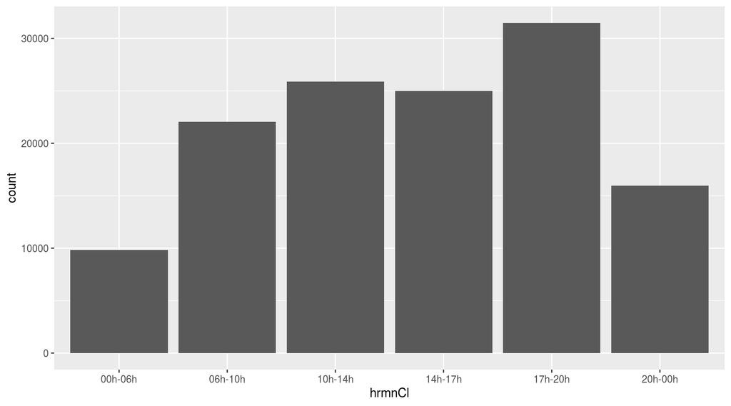

```r
ggplot(usagers)+
  aes(x=hrmnCl, y=..count..)+
  geom_bar()
```

### 5.3.2 `aes`

Les options de `aes` (pour *aesthetics*) permettent d’associer une donnée à un type de représentation :

x = axe des abscisses

y = axe des ordonnées

size = taille des points

col = couleur des points / contours

alpha = transparence

fill = couleur des applats

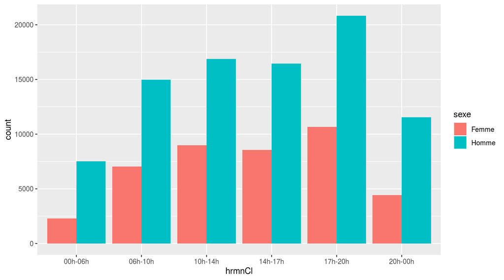

```r
ggplot(usagers)+
  aes(x=hrmnCl,  fill=sexe)+
  geom_bar(stat="count", position = "dodge") # fill, stack
```

### 5.3.3 `geom_X`

Les `geom_X` correspondent aux types de représentation graphique attendus ; Les principaux sont :

- geom_bar : Diagramme en barres
- geom_histogram : Histogramme
- geom_point : Nuage de points
- geom_boxplot : Boxplot
- geom_line : Lignes
- geom_text : Ajout de texte
- geom_label : Idem, labels
- Etc.

Suivant les `geom_X`, différentes options de représentations peuvent être attendues.

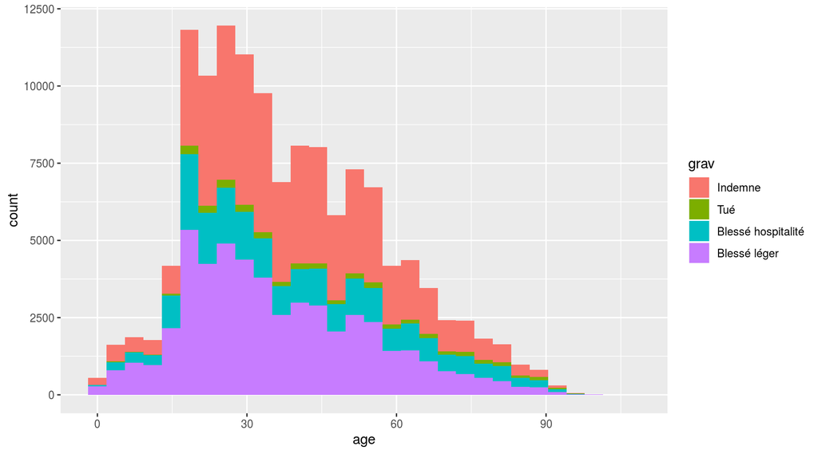

```r
ggplot(usagers)+
  aes(x=age, fill=grav)+
  geom_histogram(bins=30)
```

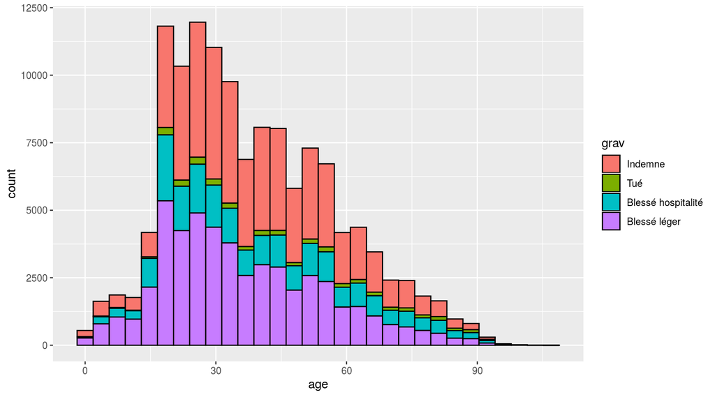

```r
ggplot(usagers)+
  aes(x=age, fill=grav)+
  geom_histogram(bins=30, col = "black")
```

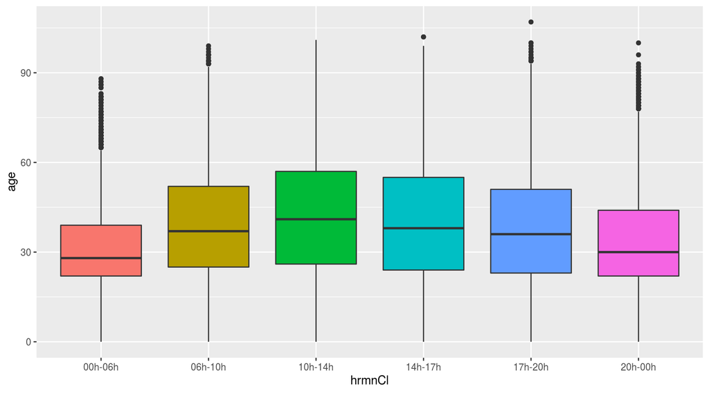

```r
ggplot(usagers) + aes(x=hrmnCl, y=age, fill = hrmnCl)+ geom_boxplot(show.legend=F)
```

### 5.3.4 Mise en forme

#### 5.3.4.1 Les titres : `labs`

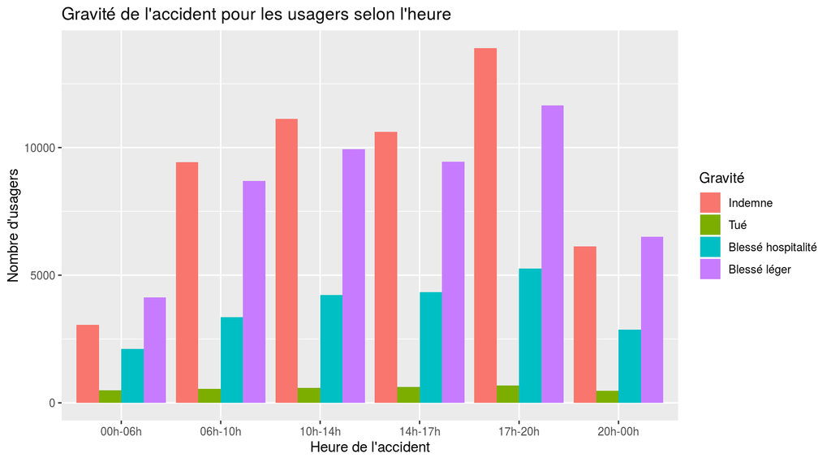

```r
ggplot(usagers)+
  aes(x=hrmnCl,fill=grav)+
  geom_bar(stat="count", position = "dodge")+
 labs(x="Heure de l'accident",
      y="Nombre d'usagers",
      fill = "Gravité",
      title="Gravité de l'accident pour les usagers selon l'heure")
```

#### 5.3.4.2 Les thèmes

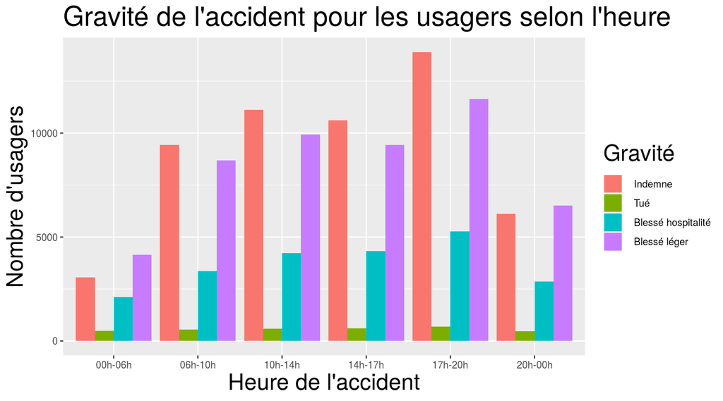

```r
ggplot(usagers)+
  aes(x=hrmnCl,fill=grav)+
  geom_bar(stat="count", position = "dodge")+
 labs(x="Heure de l'accident",
      y="Nombre d'usagers",
      fill = "Gravité",
      title="Gravité de l'accident pour les usagers selon l'heure") +
  theme(title = element_text(size=20))
```

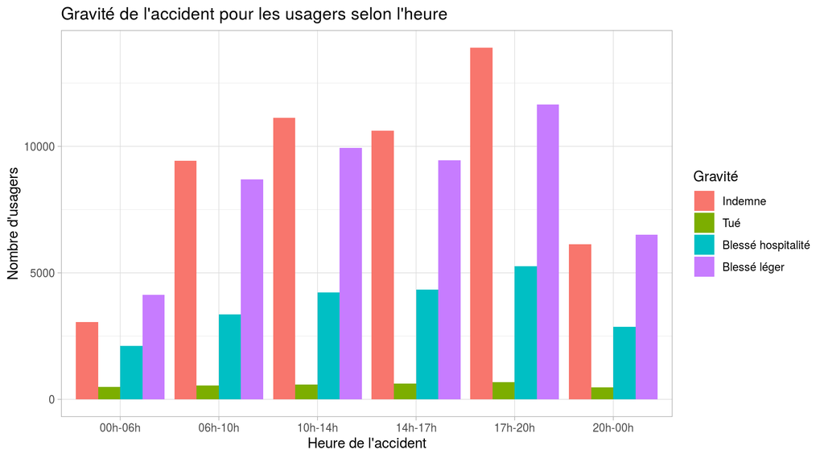

```r
ggplot(usagers)+
  aes(x=hrmnCl,fill=grav)+
  geom_bar(stat="count", position = "dodge")+
 labs(x="Heure de l'accident",
      y="Nombre d'usagers",
      fill = "Gravité",
      title="Gravité de l'accident pour les usagers selon l'heure") +
  theme_light()
```

#### 5.3.4.3 Les couleurs

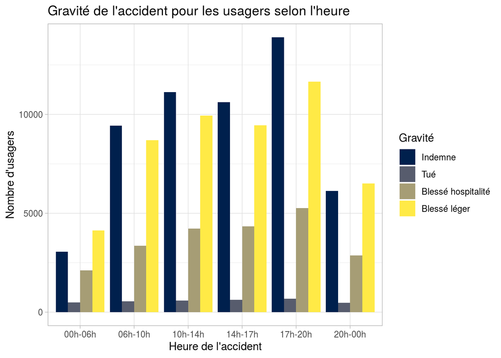

```r
ggplot(usagers)+
  aes(x=hrmnCl,fill=grav)+
  geom_bar(stat="count", position = "dodge")+
 viridis::scale_fill_viridis(discrete=T, option="E")+
 labs(x="Heure de l'accident",
      y="Nombre d'usagers",
      fill = "Gravité",
      title="Gravité de l'accident pour les usagers selon l'heure") +
  theme_light()
```

#### 5.3.4.4 Plusieurs graphiques en fonction d’une variable

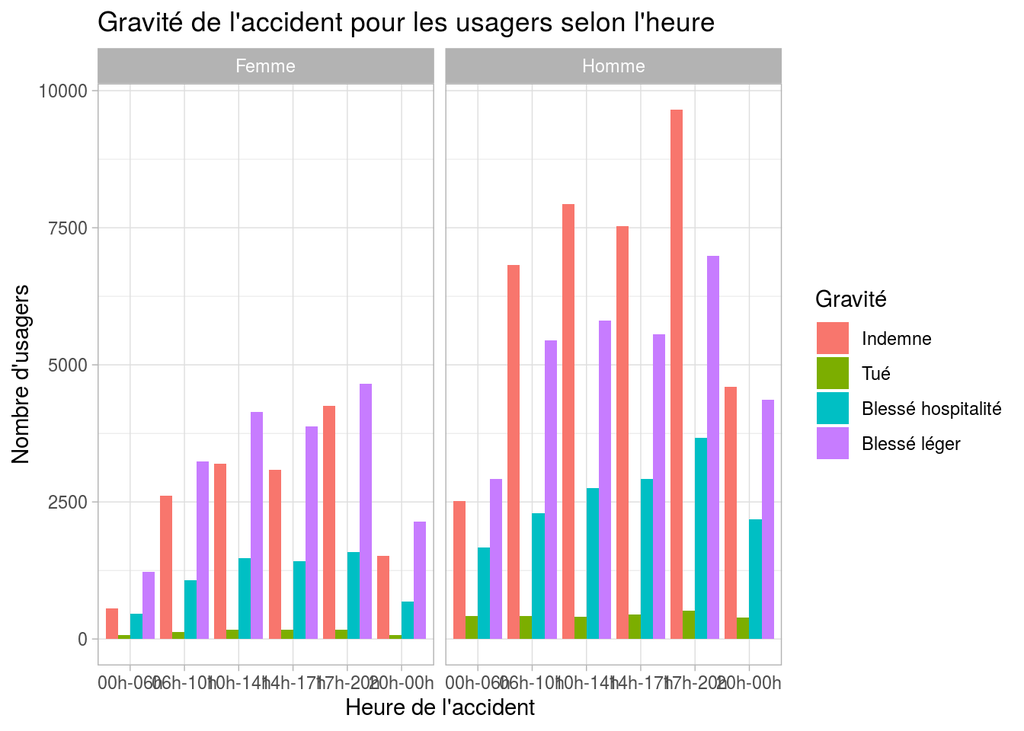

```r
ggplot(usagers)+
  aes(x=hrmnCl,fill=grav)+
  geom_bar(stat="count", position = "dodge")+
 labs(x="Heure de l'accident",
      y="Nombre d'usagers",
      fill = "Gravité",
      title="Gravité de l'accident pour les usagers selon l'heure") +
  theme_light()+
  facet_grid(. ~ sexe)
```

# 6 Ressources

**R généralités :**

- Guay, Jean-Herman. *Statistiques en sciences humaines avec R: sciences sociales et psychologie.* [Louvain-la-Neuve]; [Québec]: De Boeck ; [Presses universitaires de Laval], 2014.
- Larmarange, Joseph, et alii. «Introduction à l’analyse d’enquêtes avec R et RStudio», s.d. https://larmarange.github.io/analyse-R/
- Barnier, Julien, “R_pour_sociologues.pdf” http://www.info.univ-angers.fr/~gh/tuteurs/R_pour_sociologues.pdf
- R for data science : https://r4ds.had.co.nz/
- Nathaniel D. Phillips, YaRrr! The Pirate’s Guide to R : https://bookdown.org/ndphillips/YaRrr/

**Cheat Sheet : https://www.rstudio.com/resources/cheatsheets/**

- Rstudio : https://github.com/rstudio/cheatsheets/raw/master/rstudio-ide.pdf
- Readr : https://github.com/rstudio/cheatsheets/raw/master/data-import.pdf
- stringr : https://github.com/rstudio/cheatsheets/raw/master/strings.pdf
- dplyr : https://github.com/rstudio/cheatsheets/raw/master/data-transformation.pdf
- ggplot2 : https://github.com/rstudio/cheatsheets/raw/master/data-visualization-2.1.pdf

**Tidyverse :**

- Barnier Julien, “Introduction à R et au tidyverse”, Octobre 2017, Consulté le 25 octobre 2017 https://juba.github.io/tidyverse/index.html

**Ggplot2 :**

- http://docs.ggplot2.org/0.9.3.1/index.html
- *R graphics cookbook*, Winston Chang, O’Reilly books, 2013 : https://filesender.renater.fr/?s=download&token=ca0d7a0d-1946-63e6-c7fa-c7cb4c5c37bf
- http://www.r-graph-gallery.com/portfolio/ggplot2-package/
- http://www.stat.columbia.edu/~tzheng/files/Rcolor.pdf

**Aides en ligne et sites ressources :**

- http://stackoverflow.com/ : Large source d’informations, anglophone
- http://forums.cirad.fr/logiciel-R/ : Francophone
- http://www.statmethods.net/ : Quick-R
- http://rfunction.com/
- http://informatique-mia.inra.fr/r4ciam/
- https://cran.r-project.org/web/views/ : Packages du CRAN